# SWFWMD (STORET) Water Quality Data Cleaning

Miles Medina PhD and Christine Angelini PhD, University of Florida Center for Coastal Solutions

Aug 2, 2022

# Contents

- Overview
- Load R libraries and data
- Specify data classes
- Subset data by date
- Clean up factor levels and redundancies
- Abbreviate analyte names
- Standardize measurement units
- Remove field blanks and equipment blanks
- Standardize sample depth units
- Subset surface sample data
- Remove duplicate records
- Open-water monitoring strata
- Remove records flagged with fatal qualifier codes
- Detection limits and non-detects
- Apply thresholds to result values
- Export clean data
- References

# Overview

Data cleaning procedures described below follow the procedure developed for the CHNEP-provided dataset, and the script was implemented in R Version 4.1.0 (R Core Team, 2021).

top

# Load R libraries and data

First, we clear the global R environment and load libraries: `plyr` (Wickham, 2011), `dplyr` (Wickham et al., 2021), `tidyr` (Wickham, 2021), and `data.table` (Dowle & Srinivasan, 2021). The code automatically installs the packages if they are not already stored locally.

```r
rm(list=ls(all=TRUE))
if(!require(plyr)) { install.packages('plyr') } ;  library(plyr)
if(!require(dplyr)) { install.packages('dplyr') } ;  library(dplyr)
if(!require(tidyr)) { install.packages('tidyr') } ;  library(tidyr)
if(!require(data.table)) { install.packages('data.table') } ;  library(data.table)
```

Next, we load sample data, strata information, and value thresholds from file.

```r
dat <- read.table('STORET_Water_Quality_Results.txt',sep="|",header=TRUE,fill=TRUE)
grid.strata <- read.csv('grid-strata-associations.csv')
grid.stations <- read.csv("grid-station-associations.csv")
thresholds <- read.csv("thresholds.csv")
```

The `dat` dataframe contains 59047 rows and 25 columns, whose names are printed below.

```r
colnames(dat)
```

```
##  [1] "Org.ID"          "Org.Name"        "Station.ID"      "WBID"
##  [5] "Act.Date"        "Act.Time"        "Act.Type"        "Act.Category"
##  [9] "Act.Depth"       "Depth.Units"     "Relative.Depth"  "Characteristic"
## [13] "Result.Value"    "Result.Units"    "VQ"              "Analysis.Date"
## [17] "Analysis.Time"   "Procedure.Name"  "Comment"         "Sample.Fraction"
## [21] "MDL"             "MDL.Units"       "PQL"             "Medium"
## [25] "Matrix"
```

The `grid.strata` and `grid.stations` files specify associations between the strata, their constituent grid cells, and associated station names. The `thresholds` file contains thresholds for measured values to help us identify unreliable data.

top

# Specify data classes

Next, we store the `dat` dataframe as a new dataframe object `df` and specify the type (class) of data in some of the columns.

```r
df <- dat
df$Station.ID  <- df$Station.ID %>% as.factor()
df$Act.Type <- df$Act.Type %>% as.factor()
df$Act.Date <- df$Act.Date %>% as.Date(format="%m/%d/%Y")
df$Characteristic <- df$Characteristic %>% as.factor()
df$Result.Value <- df$Result.Value %>% as.numeric()  # "*Non-detect" coerced to NA
```

top

# Subset data by date

The trend analysis will use 10 years of sample data from 2011 through 2020. Below, we subset the data in `df` by date, store this subset as a new dataframe `df1`, and rename the `Act.Date` column to `Date`.

```r
min.date <- as.Date('2011-01-01')
max.date <- as.Date('2020-12-31')
df1 <- df[ which( df$Act.Date >= min.date & df$Act.Date <= max.date) ,]
colnames(df1)[which(colnames(df1)=='Act.Date')] <- 'Date'
```

We note that these data do not span the full 2011–2020 period, because the STORET database contains data through 2015. More recent data are available in FDEP’s WIN database.

```r
range( df1$Date )
```

```
## [1] "2011-01-04" "2015-12-09"
```

top

# Clean up factor levels and redundancies

Subsetting the data by date potentially removed instances of some factor levels from `factor` columns of `df1`. In this section, we check for redundancies in each `factor` column and remove any unused factor levels.

First, we explore the `Station.ID` column, which contains 100 unique values. The logical test below indicates that the number of factor levels is not equal to the actual number of unique values that appear in the column, so we remove unused factor levels by calling `droplevels()`.

```r
length(levels(df1$Station.ID)) == length(unique(df1$Station.ID))
```

```
## [1] FALSE
```

```r
df1$Station.ID <- droplevels(df1$Station.ID)
```

Likewise, we check the `Act.Type` and `Characteristic` columns, which do not show unused factor levels.

```r
length(levels(df1$Act.Type)) == length(unique(df1$Act.Type))
```

```
## [1] TRUE
```

```r
length(levels(df1$Characteristic)) == length(unique(df1$Characteristic))
```

```
## [1] TRUE
```

Next, we check the `Depth.Units` column. The sampling depths are consistently reported in meters.

```r
unique(df1$Depth.Units) %>% as.character()
```

```
## [1] "m"
```

The `Characteristic` column indicates the analyte associated with each record, and we see no redundancies in the analyte names.

```r
unique(df1$Characteristic) %>% sort()
```

```
##  [1] Chlorophyll a, corrected for pheophytin
##  [2] Depth
##  [3] Depth, bottom
##  [4] Dissolved oxygen (DO)
##  [5] Nitrogen, ammonia as N
##  [6] Nitrogen, Kjeldahl
##  [7] Nitrogen, mixed forms (NH3)+(NH4)+organic+(NO2)+(NO3)
##  [8] Nitrogen, Nitrite (NO2) + Nitrate (NO3) as N
##  [9] pH
## [10] Phosphorus as P
## [11] Phosphorus, orthophosphate as P
## [12] Salinity
## [13] Secchi disk depth
## [14] Specific conductance
## [15] Temperature, water
## [16] Total Organic Carbon (TOC)
## [17] Total Suspended Solids (TSS)
## [18] True Color
## [19] Turbidity
## 19 Levels: Chlorophyll a, corrected for pheophytin Depth ... Turbidity
```

However, we notice that a few analytes appearing in the CHNEP dataset do not appear in the STORET dataset (DO saturation, fecal coliform, and biological oxygen demand). In addition, several analytes appear in the STORET dataset that will not be part of our trend analysis (e.g., organic carbon, Secchi depth). Later, records associated with these superfluous analytes will be removed.

top

# Abbreviate analyte names

In a new `Analyte` column, we will abbreviate the analyte labels in the `Characteristic` column. The abbreviated labels will make it easier to refer to analytes later in this script, and they can be used to label plot axes. First, we specify the abbreviated labels and confirm that the `analytes.old` and `analytes.new` vectors are lined up properly:

```r
analytes.old <- levels(df1$Characteristic)
analytes.new <- c( 'Chl-a', NA, NA, 'DO Conc', 'NH4', 'TKN', 'TN', 'NOx', 'pH',
                   'TP', 'PO4', NA, NA, 'Sp Cond', 'Temp', NA, 'TSS', 'Color', 'Turbidity' )
cbind( analytes.old, analytes.new )
```

```
##       analytes.old                                            analytes.new
##  [1,] "Chlorophyll a, corrected for pheophytin"               "Chl-a"
##  [2,] "Depth"                                                 NA
##  [3,] "Depth, bottom"                                         NA
##  [4,] "Dissolved oxygen (DO)"                                 "DO Conc"
##  [5,] "Nitrogen, ammonia as N"                                "NH4"
##  [6,] "Nitrogen, Kjeldahl"                                    "TKN"
##  [7,] "Nitrogen, mixed forms (NH3)+(NH4)+organic+(NO2)+(NO3)" "TN"
##  [8,] "Nitrogen, Nitrite (NO2) + Nitrate (NO3) as N"          "NOx"
##  [9,] "pH"                                                    "pH"
## [10,] "Phosphorus as P"                                       "TP"
## [11,] "Phosphorus, orthophosphate as P"                       "PO4"
## [12,] "Salinity"                                              NA
## [13,] "Secchi disk depth"                                     NA
## [14,] "Specific conductance"                                  "Sp Cond"
## [15,] "Temperature, water"                                    "Temp"
## [16,] "Total Organic Carbon (TOC)"                            NA
## [17,] "Total Suspended Solids (TSS)"                          "TSS"
## [18,] "True Color"                                            "Color"
## [19,] "Turbidity"                                             "Turbidity"
```

Next, we call the `plyr::mapvalues()` function to assign the abbreviated `Analyte` labels.

```r
df1$Analyte <- mapvalues( df1$Characteristic, analytes.old, analytes.new )
analytes <- unique( df1$Analyte ) %>% sort() %>% as.character()
analytes
```

```
##  [1] "Chl-a"     "DO Conc"   "NH4"       "TKN"       "TN"        "NOx"
##  [7] "pH"        "TP"        "PO4"       "Sp Cond"   "Temp"      "TSS"
## [13] "Color"     "Turbidity"
```

Next, we remove 19119 records associated with superfluous analytes.

```r
df1 <- df1[ -which(is.na(df1$Analyte)), ]
```

Below, we display selected columns from a random set of five records in `df1`. Note that the `Characteristic` labels correspond to the abbreviated `Analyte` labels.

```r
set.seed(716241)
df1[sample(1:nrow(df1),5),c('Date','Characteristic','Analyte','Result.Value')]
```

```
##             Date                                        Characteristic Analyte
## 41453 2012-01-11                       Phosphorus, orthophosphate as P     PO4
## 12237 2014-11-05                                 Dissolved oxygen (DO) DO Conc
## 43875 2011-10-26                                    Nitrogen, Kjeldahl     TKN
## 25679 2013-07-22               Chlorophyll a, corrected for pheophytin   Chl-a
## 23788 2013-10-15 Nitrogen, mixed forms (NH3)+(NH4)+organic+(NO2)+(NO3)      TN
##       Result.Value
## 41453        0.094
## 12237        7.430
## 43875        0.668
## 25679        8.230
## 23788        1.220
```

top

# Standardize measurement units

We explore measurement units to ensure consistency across analytes and with the CHNEP dataset. We start by printing the unique values in the `Result.Units` column. We see expected measurement units but notice that in some cases, the `Result.Units` field is blank (`""`).

```r
unique(df1$Result.Units)
```

```
## [1] "deg C" "mg/l"  "None"  "uS/cm" "NTU"   "PCU"   "ug/l"  ""
```

Next, we print the units associated with each analyte. Each line of the output lists an analyte and an associated unit in the `Result.Units` column; analytes associated with multiple `Result.Units` values appear on multiple lines. Below, each analyte is associated with a single measurement unit, but the output indicates that some records for several analytes are missing units (`""`).

```r
for( i in 1:length(levels(df1$Analyte)) ){
  this.analyte <- levels(df1$Analyte)[i]
  this.units   <- unique( df1$Result.Units[which(df1$Analyte==this.analyte)] )
  cat( paste0( this.analyte, ' -- ', this.units, '\n' ) )
}
```

```
## Chl-a -- ug/l
##  Chl-a --
## DO Conc -- mg/l
## NH4 -- mg/l
##  NH4 --
## TKN -- mg/l
##  TKN --
## TN -- mg/l
##  TN --
## NOx -- mg/l
##  NOx --
## pH -- None
## TP -- mg/l
##  TP --
## PO4 -- mg/l
##  PO4 --
## Sp Cond -- uS/cm
## Temp -- deg C
## TSS -- mg/l
## Color -- PCU
## Turbidity -- NTU
```

Upon examining records with missing measurement units, we find that these are non-detects, with `NA` in the `Result.Value` column. Further, none of the records with a measured value reported (`Result.Value`) are missing units (`Result.Units`). Later, we will assign measurement values and units to the non-detect records.

```r
 df1$Result.Value[ which( df1$Result.Units=="") ] %>% unique()
```

```
## [1] NA
```

```r
 any( df1$Result.Unit[which(!is.na(df1$Result.Value))]=="" )
```

```
## [1] FALSE
```

```r
# Nutrients (mg/l to ug/l)
df1$Result.Value[ which(df1$Analyte %in% c('NH4','NOx','TN','TKN','PO4','TP') ) ] <- df1$Result.Value[ which(df1$Analyte %in% c('NH4','NOx','TN','TKN','PO4','TP') ) ]*1000
df1$Result.Units[ which(df1$Analyte %in% c('NH4','NOx','TN','TKN','PO4','TP') ) ]  <- 'ug/l'
# pH
df1$Result.Units[ which(df1$Analyte=='pH' ) ]  <- 'pH'
# Sp Cond
df1$Result.Units[ which(df1$Analyte=='Sp Cond') ]  <- 'umho'
# Temp
df1$Result.Value[ which(df1$Analyte=='Temp') ] <- df1$Result.Value[ which(df1$Analyte=='Temp') ]*1.8+32
df1$Result.Units[ which(df1$Analyte=='Temp') ]  <- 'deg F'
```

Next, we repeat the procedure above for the `MDL` and `MDL.units`, which indicate detection limits for non-detect records. Printing the MDL units associated with each analyte indicates that several should be converted for consistency with `Result.Units`.

```r
for( i in 1:length(levels(df1$Analyte)) ){
  this.analyte <- levels(df1$Analyte)[i]
  this.units   <- unique( df1$MDL.Units[which(df1$Analyte==this.analyte)] )
  cat( paste0( this.analyte, ' -- ', this.units, '\n' ) )
}
```

```
## Chl-a -- ug/l
## DO Conc --
## NH4 -- mg/l
## TKN -- mg/l
## TN -- mg/l
## NOx -- mg/l
## pH --
## TP -- mg/l
## PO4 -- mg/l
## Sp Cond --
## Temp --
## TSS -- mg/l
## Color -- PCU
## Turbidity -- NTU
```

As above, we convert/re-label MDL values and units:

```r
# Nutrients (mg/l to ug/l)
df1$MDL[ which(df1$Analyte %in% c('NH4','NOx','TN','TKN','PO4','TP') ) ] <- df1$MDL[ which(df1$Analyte %in% c('NH4','NOx','TN','TKN','PO4','TP') ) ]*1000
df1$MDL.Units[ which(df1$Analyte %in% c('NH4','NOx','TN','TKN','PO4','TP') ) ]  <- 'ug/l'
# pH
df1$MDL.Units[ which(df1$Analyte=='pH' ) ]  <- 'pH'
# Sp Cond
df1$MDL.Units[ which(df1$Analyte=='Sp Cond') ]  <- 'umho'
# Temp
df1$MDL[ which(df1$Analyte=='Temp') ] <- df1$MDL[ which(df1$Analyte=='Temp') ]*1.8+32
df1$MDL.Units[ which(df1$Analyte=='Temp') ]  <- 'deg F'
```

top

# Remove field blanks and equipment blanks

The dataset does not include any field blanks or equipment blanks (`Act.Type` column).

```r
unique(df1$Act.Type) %>% sort()
```

```
## [1] Field Msr/Obs Sample
## Levels: Field Msr/Obs Sample
```

top

# Standardize sample depth units

The `Act.Depth` and `Depth.Units` columns indicate the depths at which samples were collected. Sample depths are consistently expressed in meters in this dataset, and there are no missing depth values:

```r
unique(df1$Depth.Units) %>% as.character()
```

```
## [1] "m"
```

```r
any(is.na(df1$Act.Depth))
```

```
## [1] FALSE
```

top

# Subset surface sample data

The trend analysis will consider only surface sample data. Samples are considered to be from the surface if the `Act.Depth` value is 1 meter or less.

We subset the data for surface samples and thereby discard 11131 records:

```r
df1 <- df1[ -which( df1$Act.Depth > 1 ), ]
```

top

# Remove duplicate records

We call the function `duplicated()` to search for duplicate records in `df1` and find 0 duplicate records.

```r
any(duplicated(df1))
```

```
## [1] FALSE
```

top

# Open-water monitoring strata

The `Station.ID` column indicates the monitoring station where each sample was collected. We start by printing all unique location values and observe that all the labels are numerical.

```r
df1$Station.ID %>% unique() %>% sort()
```

```
##   [1] 670045 670046 670047 670048 670051 670052 670053 670056 670057 670058
##  [11] 670059 670062 670063 670064 670065 670066 670068 670069 670070 670071
##  [21] 670072 670076 670077 670078 670079 670080 670082 670083 670084 670085
##  [31] 670086 670087 670088 670089 670090 670091 670092 670093 670095 670096
##  [41] 670097 670098 670099 670100 670102 670103 670104 670105 670106 670107
##  [51] 670109 670110 670112 670113 670114 670115 670116 670117 670118 670119
##  [61] 670120 670121 670122 670123 670124 670125 670126 670127 670128 670129
##  [71] 670130 670132 670133 670134 670135 670136 670137 670138 670139 670140
##  [81] 670141 670142 670144 670145 670146 670147 670148 670149 670150 670151
##  [91] 670152 670153 670154 670155 670159 670160 670161 670163 735142 735151
## 100 Levels: 670045 670046 670047 670048 670051 670052 670053 670056 ... 735151
```

Further, we see that all of these monitoring locations correspond to strata grid cells.

```r
all( unique(df1$Station.ID) %in% grid.stations$Station[which(grid.stations$Agency=="SWFWMD")] )
```

```
## [1] TRUE
```

Next, we create a new `Stratum.Grid` column and assign the grid cell number corresponding to each `Station.ID`, using the `grid.stations` dataframe.

```r
df1$Stratum.Grid <- mapvalues( x = df1$Station.ID,
                              from = grid.stations$Station[ which(grid.stations$Agency=="SWFWMD") ],
                              to = grid.stations$Grid[ which(grid.stations$Agency=="SWFWMD" )],
                              warn_missing = FALSE )
```

As expected, all `Station.ID` found a matching grid cell number.

```r
any(is.na(df1$Stratum.Grid))
```

```
## [1] FALSE
```

Finally, we create a new `Stratum` column to contain the stratum name associated with each grid cell, using the `grid.strata` dataframe.

```r
df1$Stratum <- mapvalues( x = df1$Stratum.Grid,
                          from = grid.strata$Grid,
                          to = grid.strata$Stratum,
                          warn_missing = FALSE )
```

And, as expected, all `Stratum.Grid` numbers found a matching stratum.

```r
any(is.na(df1$Stratum))
```

```
## [1] FALSE
```

Below, we print a random sample of 10 stations, grids, and strata.

```r
set.seed(34618)
df1[ sample(1:nrow(df1),10), c("Station.ID","Stratum.Grid","Stratum") ]
```

```
##       Station.ID Stratum.Grid                    Stratum
## 2527      670071           44          Tidal Peace River
## 9541      670132          113                  Cape Haze
## 17295     670064           35          Tidal Peace River
## 12956     670079           53 West Wall Charlotte Harbor
## 92        670147          129                  Cape Haze
## 3280      670099           74 East Wall Charlotte Harbor
## 13209     670152          134 East Wall Charlotte Harbor
## 28567     670137          118                  Cape Haze
## 44224     670103           78 West Wall Charlotte Harbor
## 32872     670090           65 West Wall Charlotte Harbor
```

top

# Remove records flagged with fatal qualifier codes

Fatal qualifier codes indicate unreliable data that should not be used for analysis. First, we print all unique qualifier codes (`VQ` column) found in `df1`, and we see several fatal qualifier codes.

```r
df1$VQ %>% unique() %>% sort()
```

```
## [1] ""   "I"  "J"  "K"  "Q"  "U"  "UJ"
```

We remove records flagged with fatal qualifier code by specifying a vector of fatal codes (`invalid.codes`) and defining a `find.invalid()` function to identify fatally flagged records. Because each `VQ` string may contain multiple characters, the function parses each string into single characters and checks for matches against the specified `invalid.codes`.

```r
invalid.codes <- c("*","?","A","B","G","H","J","K","L","N","O","Q","T","V","Y","Z")
find.invalid <- function( QUALIFIER, INVALID=invalid.codes ){  # QUALIFER arg is a character string
  input.code <- QUALIFIER %>% strsplit(split='') %>% unlist() # parse the string into single characters
  invalid <- input.code %in% INVALID %>% any()  # check if any input characters match INVALID
  return( invalid )  # return TRUE or FALSE
}
```

We apply `find.invalid()` to identify row indices containing fatal codes, remove these records, and store the result in a new dataframe `df2`.

```r
invalid.rows <- apply( matrix(df1$VQ,ncol=1), 1, find.invalid ) %>% which()
if( length(invalid.rows)>0 ){
  df2 <- df1[ -invalid.rows, ]
} else {
  df2 <- df1
}
df2$VQ <- df2$VQ %>% as.factor()
```

A total of 58 fatally flagged records are removed from the dataset. The remaining qualifier codes appearing in `df2` are printed below.

```r
df2$VQ %>% unique() %>% as.character()
```

```
## [1] ""  "I" "U"
```

top

# Detection limits and non-detects

We identify all non-detect records and label them in a new `logical` column: `Non_detect`. Because qualifier code strings may contain multiple characters, we define a function, `find.U()`, that determines whether a “U” appears in a qualifier code string. For instance, the function will return `TRUE` for “U”, “u”, and “UI” and `FALSE` for “P”, “I”, and “IC”.

```r
# Define function to find records flagged with 'U'
find.U <- function( QUALIFIER, CODE='U' ){  # QUALIFER argument is a character string
  QUALIFIER <- toupper(QUALIFIER)  # capitalize the input
  input.code <- QUALIFIER %>% strsplit(split='') %>%
                           unlist()  # parse the qualifier string into single characters
  u.code <- input.code %in% CODE %>% any()  # check if any input characters contain U
  return( u.code )  # return TRUE or FALSE
}  #  // end find.U() function
# Apply find.U() and store results in new column
df2$Non_detect <- apply( matrix(df2$VQ,ncol=1), 1, find.U )
```

We query `df2` to check whether there are any MDL values missing among non-detect records, and we find that MDL values are provided for all non-detect records.

```r
any( is.na(df2$MDL) & df2$Non_detect==TRUE )
```

```
## [1] FALSE
```

Next, we assign the `MDL` as the `Result.Value` for all non-detects.

```r
df2$Result.Value[ which(df2$Non_detect==TRUE) ] <- df2$MDL[ which(df2$Non_detect==TRUE) ]
df2$Result.Units[ which(df2$Non_detect==TRUE) ] <- df2$MDL.Units[ which(df2$Non_detect==TRUE) ]
```

```r
for( i in 1:length(levels(df2$Analyte)) ){
  this.analyte <- levels(df2$Analyte)[i]
  this.units   <- unique( df2$Result.Units[which(df2$Analyte==this.analyte)] )
  cat( paste0( this.analyte, ' -- ', this.units, '\n' ) )
}
```

```
## Chl-a -- ug/l
## DO Conc -- mg/l
## NH4 -- ug/l
## TKN -- ug/l
## TN -- ug/l
## NOx -- ug/l
## pH -- pH
## TP -- ug/l
## PO4 -- ug/l
## Sp Cond -- umho
## Temp -- deg F
## TSS -- mg/l
## Color -- PCU
## Turbidity -- NTU
```

```r
df2$Result.Units <- df2$Result.Units %>% as.factor()
```

top

# Apply thresholds to result values

We explore the data distributions for each analyte to identify suspect values, and we discard values outside specified minimum and maximum thresholds.

We begin by visualizing the data distributions for each analyte. The minimum and maximum reported values (`Result.Value`) are printed near the top right corner of each histogram.

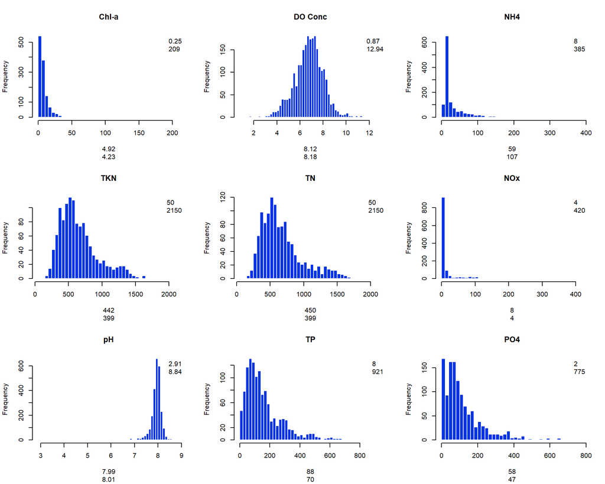

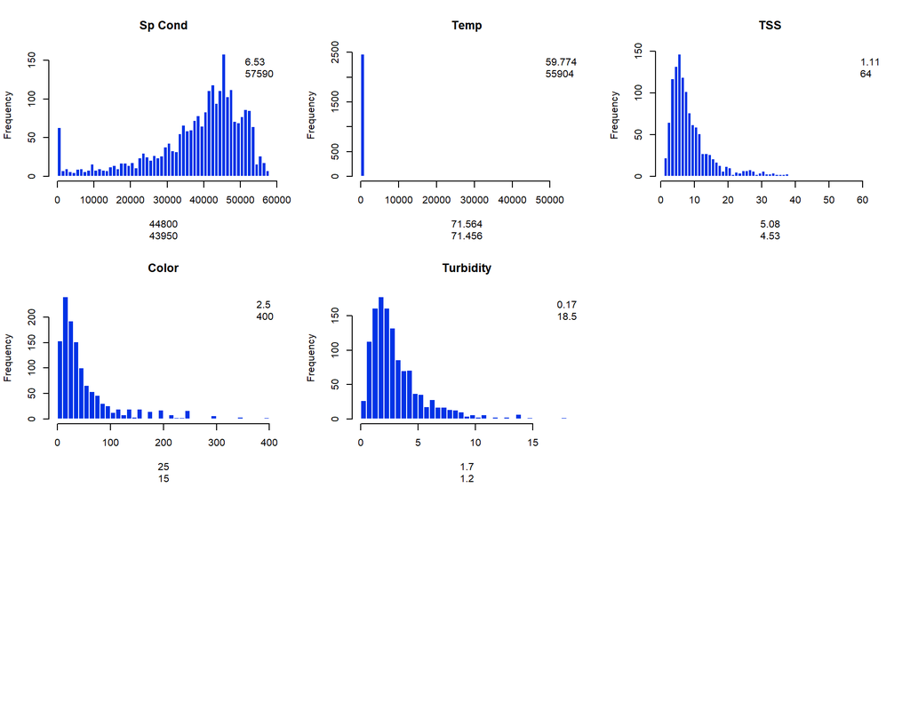

```r
par(mfrow=c(3,3))
for( i in 1:length(analytes) ){
  this.analyte <- analytes[i]
  this.unit    <- unique( df2$Result.Value[ which(df2$Analyte==this.analyte) ] )
  hist( df2$Result.Value[ which(df2$Analyte==this.analyte) ], breaks=50,
        border=rgb(1,1,1,1), col=rgb(0,0.2,0.9,1),
        main=this.analyte, xlab=this.unit
        )
  legend('topright',bty='n',legend=range(df2$Result.Value[which(df2$Analyte==this.analyte)]))
}
```

The threshold values are stored in the `thresholds.csv` file, which was loaded as the `threshold` dataframe at the top of this script and is printed below. The `low` and `high` columns contain the threshold values for each analyte. Specification of thresholds was informed by the distributions of the data provided by CHNEP and by domain knowledge. For several analytes, no maximum threshold is specified, to avoid discarding unusually large albeit plausible reported values.

```r
thresholds[,c('analyte','low','high','unit')]
```

```
##      analyte    low   high        unit
## 1      Color  0.001    600         PCU
## 2        BOD  0.001     NA        mg/l
## 3      Chl-a  0.001     NA        ug/l
## 4    DO Conc  0.000     20        mg/l
## 5     DO Sat  0.000    200 percent (%)
## 6      Fecal  0.000     NA   cfu/100ml
## 7         TN  0.001     NA        ug/l
## 8        NH4  0.001     NA        ug/l
## 9        TKN  0.001     NA        ug/l
## 10       NOx  0.001     NA        ug/l
## 11        pH  2.000     14          pH
## 12        TP  0.001     NA        ug/l
## 13       PO4  0.001     NA        ug/l
## 14   Sp Cond 50.000 100000        umho
## 15      Temp 23.000    122       deg F
## 16       TSS  0.001   1000        mg/l
## 17 Turbidity  0.001     NA         NTU
```

```r
    threshold.screening <- data.frame( analyte=analytes, n.removals=NA )
    # Loop over analytes and screen out data outside of specified thresholds
    for( i in 1:length(analytes) ){
      # Verify threshold units match data units
      this.unit <- unique(df2$Result.Units[which(df2$Analyte==analytes[i])])
      t.idx <- which(thresholds$analyte==analytes[i])
      if( thresholds$unit[t.idx] != this.unit ){
        stop(paste("Threshold unit doesn't match data (",analytes[i],")."))
        } # // end if()
      # Remove data outside of specified thresholds
      outside.idx <- which( df2$Analyte==analytes[i] &
                            (df2$Result.Value<thresholds$low[t.idx] |
                             df2$Result.Value>thresholds$high[t.idx]) )
      if( length(outside.idx)>0 ){
        df2 <- df2[-outside.idx,]
      }  # // end if()
      # Add summary entry
      threshold.screening$n.removals[i] <- length(outside.idx)
    }  # // end i loop
    # Write summary to file
    write.csv(threshold.screening,"threshold.results.STORET.csv",row.names=FALSE)
```

Below, we print `threshold.screening`, which reports the number of records discarded for each analyte. In total, 46 records were discarded.

```r
threshold.screening
```

```
##      analyte n.removals
## 1      Chl-a          0
## 2    DO Conc          0
## 3        NH4          0
## 4        TKN          0
## 5         TN          0
## 6        NOx          0
## 7         pH          0
## 8         TP          0
## 9        PO4          0
## 10   Sp Cond         42
## 11      Temp          4
## 12       TSS          0
## 13     Color          0
## 14 Turbidity          0
```

Finally, we re-run the plotting loop above to visualize the data distributions following the threshold screening. Comparing the two sets of histograms, we observe that the distributions for the affected analytes have changed.

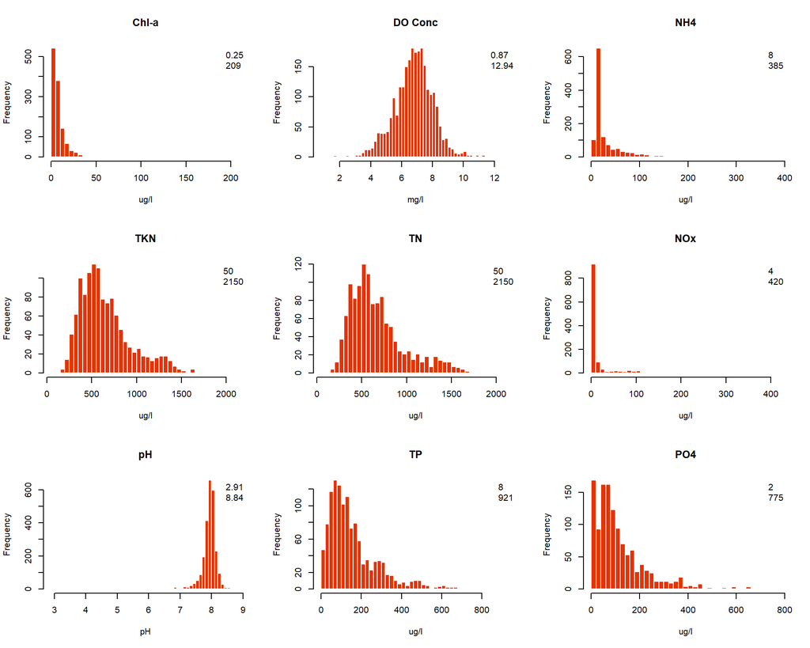

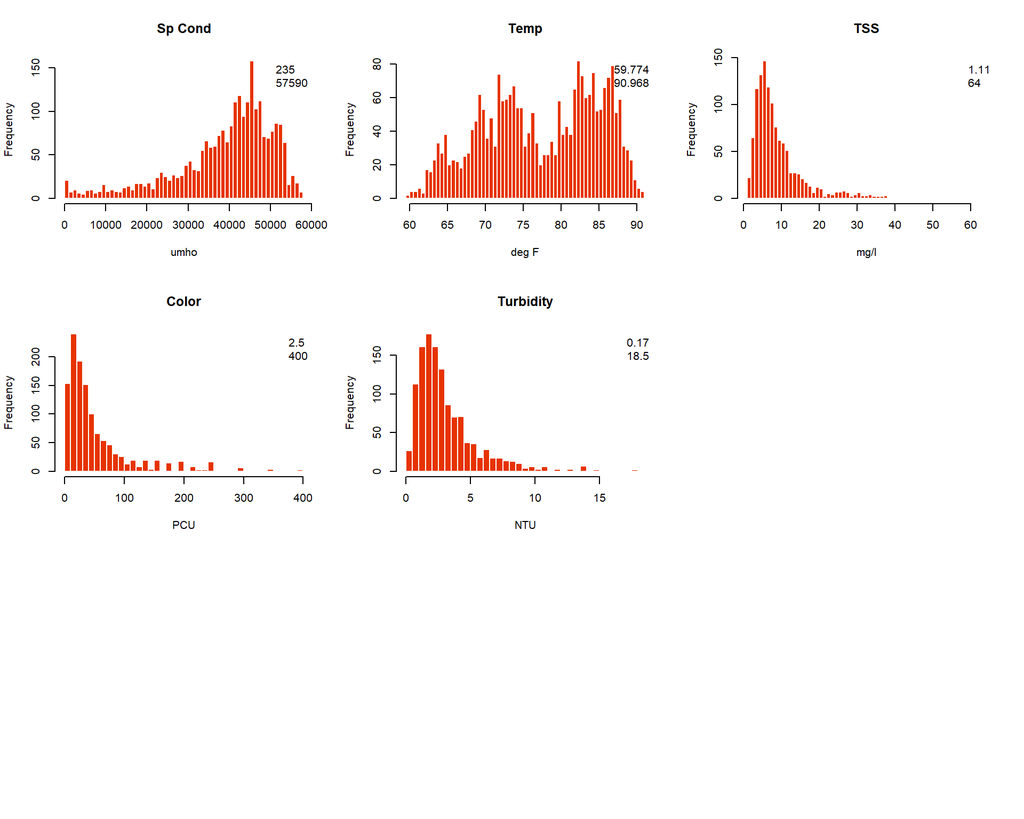

```r
par(mfrow=c(3,3))
for( i in 1:length(analytes) ){
  this.analyte <- analytes[i]
  this.unit    <- unique( df2$Result.Units[ which(df2$Analyte==this.analyte) ] )
  if(this.unit[1]=="None"){ this.unit<-'' }
  hist( df2$Result.Value[ which(df2$Analyte==this.analyte) ], breaks=50,
        border=rgb(1,1,1,1), col=rgb(0.9,0.2,0,1),
        main=this.analyte, xlab=this.unit
        )
  legend('topright',bty='n',legend=range(df2$Result.Value[which(df2$Analyte==this.analyte)]))
}
```

top

# Export clean data

We export the clean dataset (`df2`), which contains 22051 rows. We save the data to a csv file and an RData file.

```r
write.csv( df2, "clean-data_SWFWMD-STORET-WQ_2011-2020.csv", row.names=FALSE )
save( df2, file="clean-data_SWFWMD-STORET-WQ_2011-2020.RData" )
```

top

# References

Dowle, M. & Srinivasan, A. (2021). data.table: Extension of `data.frame`. R package version 1.14.0. https://CRAN.R-project.org/package=data.table

R Core Team (2021). R: A Language and Environment for Statistical Computing. R Foundation for Statistical Computing, Vienna, Austria. https://www.R-project.org/

Wickham, H. (2011). The Split-Apply-Combine Strategy for Data Analysis. *Journal of Statistical Software*, 40(1): 1-29. http://www.jstatsoft.org/v40/i01/

Wickham, H. (2021). tidyr: Tidy Messy Data. R package version 1.1.3. https://CRAN.R-project.org/package=tidyr

Wickham, H., François, R., Henry, L. & Müller, K. (2021). dplyr: A Grammar of Data Manipulation. R package version 1.0.6. https://CRAN.R-project.org/package=dplyr

top